# Feed e Boletins | Jornal Econômico do Tocantins

JET

**Jornal Econômico do Tocantins** Observatório & Jornalismo de Dados

PALMAS — TOCANTINS · FEED EDITORIAL & PUBLICAÇÕES ANÁLISES ASSINADAS POR ECONOMISTAS

# Feed Econômico e Boletins

Acompanhamento conjuntural, boletins mensais, dossiês setoriais e cartas de conjuntura sobre a economia tocantinense.

Edição Especial · Carta de Conjuntura

## Carta de Conjuntura Econômica do Tocantins

Relatório analítico completo elaborado por Lorenzo Costa e Tarcisio Iago integrando atividade econômica, trabalho, comércio exterior, finanças públicas, empresas e agropecuária estadual.

1. Visão Intersetorial · 2. Atividade e PIB · 3. Emprego · 4. Comércio Exterior · 5. Finanças Públicas · 6. Ambiente Empresarial · 7. Agropecuária · 8. Municípios

Baixar Carta (17 págs) ↓ Abrir no navegador →

Boletim Flash · Produto Interno Bruto e Contas Regionais do Tocantins 1º Trimestre de 2026

Boletim Flash — PIB Trimestral do Tocantins e Comparativo Setorial com o Brasil

- PIB NOMINAL (TOCANTINS): R$ 25,8 Bi ▼ 1,3% (Ref.: T1 2026 (SEPLAN-TO))
- IMPOSTOS LÍQUIDOS (TO): R$ 2,26 Bi ▼ 0,2% (Preços Correntes e Var. Dessaz.)

Indústria (+3,1%) e Serviços (+1,5%) lideram a expansão trimestral dessazonalizada no Tocantins, compensando a acomodação sazonal da Agropecuária (-7,2%) e mantendo o PIB nominal trimestral em R$ 25,8 bilhões.

**Lorenzo Costa** · Graduado em Economia  
14/11/2026

Ler matéria → Baixar PDF ↓

Boletim Flash · Panorama Macroeconômico do Tocantins Novembro/2026

Boletim Flash — Visão Geral: Pulso Macroeconômico de Curto Prazo do Tocantins

- VAR. PIB TRIMESTRAL (TO): -1,3% (Série c/ Ajuste Sazonal X-13)
- TAXA DE DESOCUPAÇÃO: 4,1% (PNAD Contínua Trimestral / IBGE)

O painel antecedente aponta manutenção do baixo desemprego estadual (4,1%) e ritmo consistente de abertura de novos CNPJs (2.760 no mês), amortecendo oscilações sazonais da atividade primária e da arrecadação tributária.

**Lorenzo Costa** · Graduado em Economia  
14/11/2026

Ler matéria → Baixar PDF ↓

Boletim Flash · Dinâmica Empresarial, Simples Nacional e Quadro Societário (TO) Outubro/2026

Boletim Flash — Dinâmica Empresarial, Simples Nacional e Quadro Societário (QSA)

- CNPJS ATIVOS (ESTOQUE): 167.565 (Saldo 12m: + 15.608)
- MEI / MICROEMPRESAS: 52,9% / 34,0% (Pequenos Negócios: 86,9%)

O Tocantins atinge 167.565 CNPJs ativos (+2.760 novas inscrições no mês), com 86,9% concentrados em MEIs e Microempresas, 164.996 optantes pelo Simples Nacional e tempo médio de abertura de 18,5 horas.

**Tarcisio Iago** · Economista  
14/11/2026

Ler matéria → Baixar PDF ↓

Dossiê Anual · Mercado de Trabalho: Novo CAGED, RAIS e PNAD Contínua (TO) Balanço Anual / 12 Meses (2025–2026)

Dossiê Anual — Mercado de Trabalho Formal (RAIS e Novo CAGED) e PNAD nas 27 UFs

- ESTOQUE RAIS (2025): 437.580 (Estab. Ativos: 33.198)
- SALDO CAGED (09/26): +716 (Adm: 11.263 | Desl: 10.547)

Com 437.580 vínculos formais ativos na RAIS (em 33.198 estabelecimentos), remuneração média de R$ 4.022,93 e taxa de desocupação de apenas 4,1% na PNAD Contínua, o Tocantins consolida uma das melhores trajetórias laborais do país em 12 meses.

**Tarcisio Iago** · Economista  
14/11/2026

Ler matéria → Baixar PDF ↓

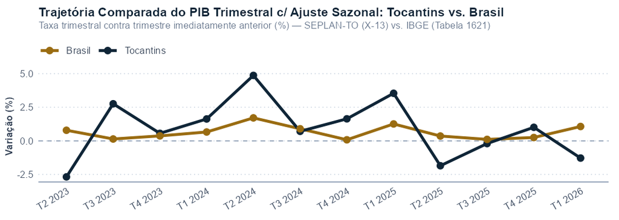

Dossiê Anual · Produto Interno Bruto e Contas Regionais do Tocantins Consolidado Anual / Últimos 4 Trimestres (2025–2026)

Dossiê Anual — PIB do Tocantins, Séries Dessazonalizadas e Contas Regionais

- PIB NOMINAL (TOCANTINS): R$ 25,8 Bi ▼ 1,3% (Ref.: T1 2026 (SEPLAN-TO))
- IMPOSTOS LÍQUIDOS (TO): R$ 2,26 Bi ▼ 0,2% (Preços Correntes e Var. Dessaz.)

Sob a ótica anualizada de quatro trimestres e das Contas Regionais do IBGE (Tabela 5938), o Tocantins sustenta ganho consistente de participação na Região Norte e no Brasil, combinando pujança primária com densificação industrial e de serviços nos dez maiores municípios.

**Lorenzo Costa** · Graduado em Economia  
14/11/2026

Ler matéria → Baixar PDF ↓

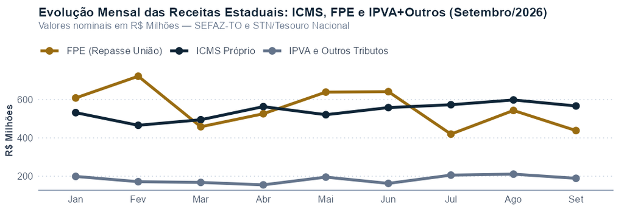

Dossiê Anual · Arrecadação Tributária e Transferências Constitucionais (TO) Acumulado no Exercício e Série Plurianual (2023–2026)

Dossiê Anual — Arrecadação Tributária e Finanças Públicas do Tocantins (2023–2026)

- RECEITA TOTAL DO MÊS: R$ 1,19 Bi (Ref.: 09/26)
- ARRECADAÇÃO DE ICMS: R$ 566,48 Mi (Var. Mês: -5,25% | YoY: +1.1%)

**Lorenzo Costa** · Graduado em Economia  
14/11/2026

Ler matéria → Baixar PDF ↓

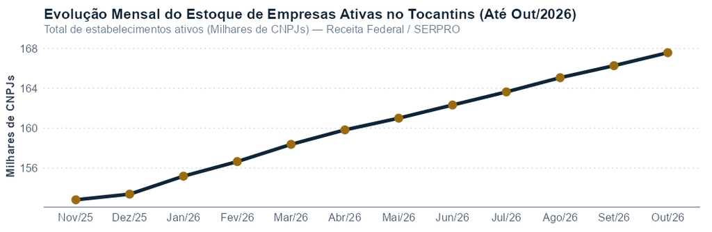

Dossiê Anual · Dinâmica Empresarial, Simples Nacional e Quadro Societário (TO) Acumulado em 12 Meses (Novembro/2025 a Outubro/2026)

Dossiê Anual — Demografia Empresarial, Simples Nacional e Quadro Societário (QSA)

- CNPJS ATIVOS (ESTOQUE): 167.565 (Saldo 12m: + 15.608)
- MEI / MICROEMPRESAS: 52,9% / 34,0% (Pequenos Negócios: 86,9%)

**Lorenzo Costa** · Graduado em Economia  
14/11/2026

Ler matéria → Baixar PDF ↓

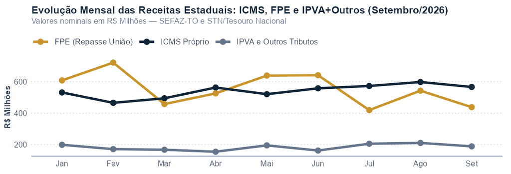

Boletim Flash · Arrecadação Tributária e Transferências Constitucionais (TO) Outubro/2026

- RECEITA TOTAL DO MÊS: R$ 1,19 Bi (Ref.: 09/26)
- ARRECADAÇÃO DE ICMS: R$ 566,48 Mi (Var. Mês: -5,25% | YoY: +1.1%)

O desempenho positivo da arrecadação tributária própria reflete o maior giro mercantil no corredor logístico da BR-153 e a expansão do consumo interno no Estado.

**Lorenzo Costa** · Graduado em Economia  
29/10/2026

Ler matéria → Baixar PDF ↓

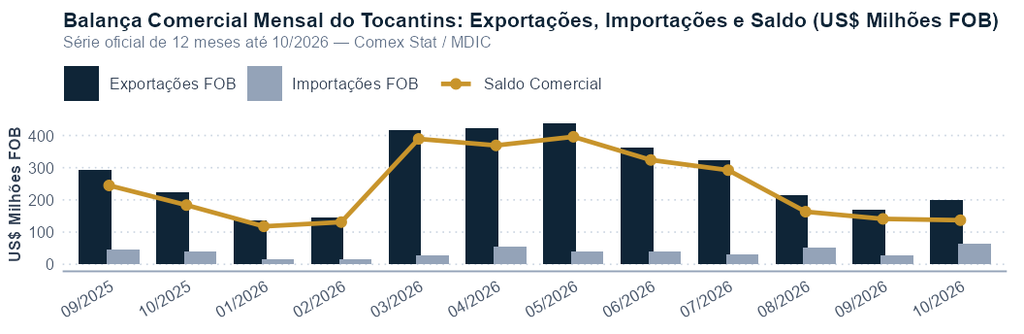

Boletim Flash · Comércio Exterior e Inserção Internacional do Tocantins Outubro/2026

Balança comercial do Tocantins mantém superávit robusto no mês puxada pelo complexo soja e carnes

- EXPORTAÇÕES (TO): US$ 200,89 Mi (Ref.: 10/2026 (Peso: 289.390 t))
- IMPORTAÇÕES (TO): US$ 63,95 Mi (Ref.: 10/2026 (Peso: 148.241 t))

**Tarcisio Iago** · Economista  
30/10/2026

Ler matéria → Baixar PDF ↓

Boletim Flash · Mercado de Trabalho: Novo CAGED, RAIS e PNAD Contínua (TO) Outubro/2026

Mercado de trabalho formal no Tocantins mantém geração líquida positiva puxada por Serviços e Construção

- ESTOQUE RAIS (2025): 437.580 (Estab. Ativos: 33.198)
- SALDO CAGED (09/26): +716 (Adm: 11.263 | Desl: 10.547)

**Tarcisio Iago** · Economista  
29/10/2026

Ler matéria → Baixar PDF ↓

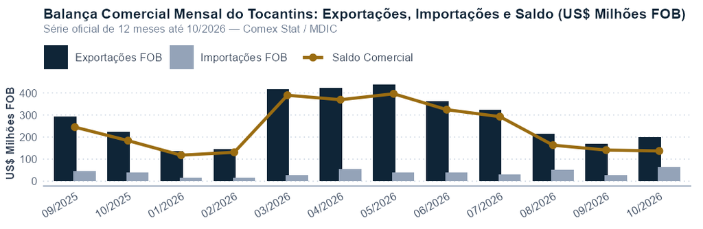

Dossiê Anual · Comércio Exterior e Inserção Internacional do Tocantins Consolidado 2026

Balanço Consolidado do Comércio Exterior Tocantinense: Superávit estrutural e avanço das cadeias agroindustriais

- EXPORTAÇÕES (TO): US$ 200,89 Mi (Ref.: 10/2026 (Peso: 289.390 t))
- IMPORTAÇÕES (TO): US$ 63,95 Mi (Ref.: 10/2026 (Peso: 148.241 t))

**Tarcisio Iago** · Economista  
29/10/2026

Ler matéria → Baixar PDF ↓

#### Economistas do JET

##### Tarcisio Iago

Economista

Economista no Jornal Econômico do Tocantins (JET). Responsável pelas análises de mercado de trabalho formal, comércio exterior e dinâmica empresarial regional.

##### Lorenzo Costa

Graduado em Economia

Graduado em Economia e editor do Jornal Econômico do Tocantins (JET). Atua em macroeconomia regional, séries dessazonalizadas, contas regionais e finanças públicas.

#### Leia também

01

Boletim Flash — PIB Trimestral do Tocantins e Comparativo Setorial com o BrasilLorenzo Costa · 1º Trimestre de 2026

02

Boletim Flash — Visão Geral: Pulso Macroeconômico de Curto Prazo do TocantinsLorenzo Costa · Novembro/2026

03

Boletim Flash — Dinâmica Empresarial, Simples Nacional e Quadro Societário (QSA)Tarcisio Iago · Outubro/2026

04

Dossiê Anual — Mercado de Trabalho Formal (RAIS e Novo CAGED) e PNAD nas 27 UFsTarcisio Iago · Balanço Anual / 12 Meses (2025–2026)

#### Receba por E-mail

Cadastre-se via Substack para receber novos boletins e a Carta de Conjuntura.

### Leituras Completas e Séries Históricas

Edições integrais assinadas pelos economistas do JET

Boletim Flash · Boletim Flash — PIB Trimestral (TO) · 1º Trimestre de 2026

Baixar em PDF ↓

## Boletim Flash — PIB Trimestral do Tocantins e Comparativo Setorial com o Brasil

Pareamento lado a lado entre a série dessazonalizada X-13ARIMA-SEATS (SEPLAN-TO) e a Tabela 1621 do IBGE, acrescido das Contas Regionais (Tabela 5938)

**Por Lorenzo Costa** · Graduado em Economia

Graduado em Economia pela UFT e editor do Jornal Econômico do Tocantins (JET). Atua na análise macroeconômica, dessazonalização de séries temporais e inteligência de dados econômicos.

Fechamento: 14/11/2026 · Fontes Primárias: SEPLAN-TO (X-13ARIMA-SEATS) e IBGE/SIDRA (Tabelas 1621, 1846, 5932 e 5938)

**Síntese Executiva:** Indústria (+3,1%) e Serviços (+1,5%) lideram a expansão trimestral dessazonalizada no Tocantins, compensando a acomodação sazonal da Agropecuária (-7,2%) e mantendo o PIB nominal trimestral em R$ 25,8 bilhões.

PIB NOMINAL (TOCANTINS)

R$ 25,8 Bi ▼ 1,3%

Ref.: T1 2026 (SEPLAN-TO)

IMPOSTOS LÍQUIDOS (TO)

R$ 2,26 Bi ▼ 0,2%

Preços Correntes e Var. Dessaz.

PIB NOMINAL (BRASIL)

R$ 3,43 Tri ▲ 0,5%

IBGE Tabelas 1846 / 5932

Desempenho Setorial (do maior crescimento ao menor)

1º Indústria

▲ + 3,1%

Maior crescimento trimestral

2º Serviços

▲ + 1,5%

Desempenho positivo na margem

3º Agropecuária

▼ - 7,2%

Retração trimestral na margem

Síntese dos Indicadores no Período

- **PIB Trimestral do Tocantins (Ajuste Sazonal X-13):** PIB Trimestral do Tocantins (Ajuste Sazonal X-13) apresentou acomodação negativa de -1,28%. (patamar atual: R$ 25,8 Bi ▼ 1,3%)
- **PIB Trimestral do Brasil (IBGE Tabela 1621):** PIB Trimestral do Brasil (IBGE Tabela 1621) avançou +1,07% em trajetória de expansão gradual. (patamar atual: R$ 3,43 Tri ▲ 0,5%)
- **1º Setor em Desempenho (Indústria):** 1º Setor em Desempenho (Indústria) avançou +3,07% em trajetória de expansão gradual. (patamar atual: ▲ + 3,1%)
- **3º Setor em Desempenho (Agropecuária):** 3º Setor em Desempenho (Agropecuária) recuou -7,16%, sinalizando desaceleração relevante no período. (patamar atual: ▼ - 7,2%)

01. Panorama Estatístico e Evidência Empírica

O PIB Nominal do Tocantins atingiu **R$ 25,8 Bi ▼ 1,3%** no trimestre de referência (**T1 2026**), frente a **R$ 3,43 Tri ▲ 0,5%** na economia brasileira. No pareamento setorial dessazonalizado (X-13ARIMA-SEATS vs. Tabela 1621 do IBGE), liderou o desempenho estadual o setor de **Indústria (▲ + 3,1%)**, seguido por **Serviços (▲ + 1,5%)** e **Agropecuária (▼ - 7,2%)**.

Comparativo Lado a Lado: Tocantins (X-13) vs. Brasil (Tabela 1621 IBGE)

| Trimestre | PIB TO: Índ. (Var.) | PIB BR: Índ. (Var.) | Agro TO/BR | Ind. TO/BR | Serv. TO/BR |
| --- | --- | --- | --- | --- | --- |
| T4 2024 | 177.2 (+1.64%) | 191.4 (+0.08%) | +17.1% / -2.2% | +0.1% / +0.3% | -0.7% / +0.0% |
| T1 2025 | 183.5 (+3.54%) | 193.8 (+1.26%) | +3.5% / +16.1% | -3.3% / +0.0% | +2.1% / +0.2% |
| T2 2025 | 180.1 (-1.85%) | 194.5 (+0.36%) | -1.1% / -3.2% | +5.9% / +0.7% | -1.1% / +0.8% |
| T3 2025 | 179.7 (-0.20%) | 194.7 (+0.11%) | -4.6% / +0.5% | -0.7% / +0.6% | +0.5% / +0.3% |
| T4 2025 | 181.6 (+1.01%) | 195.2 (+0.25%) | +6.5% / +0.7% | -3.3% / -0.7% | +1.4% / +0.6% |
| T1 2026 | 179.2 (-1.28%) | 197.3 (+1.07%) | -7.2% / +2.2% | +3.1% / +1.2% | +1.5% / +0.4% |

Fonte: SEPLAN-TO e IBGE/SIDRA (Tabela 1621).

Contas Regionais do Brasil (IBGE - Tabela 5938): PIB e Valor Adicionado do Tocantins

| Ano | PIB (R$ Mi) | Impostos (R$ Mi) | VA Agro (R$ Mi) | VA Ind. (R$ Mi) | VA Serv. (R$ Mi) | Part. Norte / BR |
| --- | --- | --- | --- | --- | --- | --- |
| 2019 | R$ 39.355,9 | R$ 3.817,5 | R$ 5.036,9 | R$ 4.211,5 | R$ 26.290,1 | 9.36% / 0.53% |
| 2020 | R$ 43.649,8 | R$ 4.140,9 | R$ 8.033,2 | R$ 4.408,4 | R$ 27.067,3 | 9.13% / 0.57% |
| 2021 | R$ 51.780,8 | R$ 5.085,4 | R$ 13.364,4 | R$ 5.000,3 | R$ 28.330,7 | 9.18% / 0.57% |
| 2022 | R$ 58.208,8 | R$ - | R$ - | R$ - | R$ - | 10.13% / 0.58% |
| 2023 | R$ 64.317,7 | R$ - | R$ - | R$ - | R$ - | 10.10% / 0.59% |

Fonte: IBGE — Contas Regionais do Brasil (Tabela 5938).

02. Análise de Conjuntura e Leitura Setorial

A comparação direta entre a série trimestral do Tocantins — ajustada sazonalmente pelo método X-13ARIMA-SEATS — e a Tabela 1621 do IBGE para o Brasil evidencia uma mudança importante nos vetores de tração de curto prazo da economia estadual. No trimestre mais recente contra o trimestre imediatamente anterior, a Indústria tocantinense avançou 3,1% e o setor de Serviços cresceu 1,5%, superando o ritmo médio nacional em ambos os grupamentos.

Por sua vez, as Contas Regionais do Brasil (Tabela 5938 do IBGE) confirmam o ganho estrutural de participação do Tocantins tanto na Região Norte quanto no Produto Interno Bruto brasileiro, sustentado pela expansão contínua do Valor Adicionado Bruto da agropecuária, da agroindústria e dos serviços logísticos.

03. Perspectivas e Cenários

O desempenho positivo dos setores secundário e terciário na margem sinaliza maior diversificação produtiva intraestadual, reduzindo a volatilidade macroeconômica nos trimestres de entressafra agrícola.

**Versão para impressão:** Baixe esta edição completa diagramada em PDF.Baixar Edição em PDF ↓

Boletim Flash · Boletim Flash — Visão Geral da Economia · Novembro/2026

Baixar em PDF ↓

## Boletim Flash — Visão Geral: Pulso Macroeconômico de Curto Prazo do Tocantins

Monitoramento integrado das variações entre períodos subsequentes em atividade, mercado de trabalho, arrecadação de ICMS e abertura de empresas

**Por Lorenzo Costa** · Graduado em Economia

Graduado em Economia pela UFT e editor do Jornal Econômico do Tocantins (JET). Atua na análise macroeconômica, dessazonalização de séries temporais e inteligência de dados econômicos.

Fechamento: 14/11/2026 · Fontes Primárias: SEPLAN-TO, IBGE/SIDRA, SEFAZ-TO, Receita Federal e MTE

**Síntese Executiva:** O painel antecedente aponta manutenção do baixo desemprego estadual (4,1%) e ritmo consistente de abertura de novos CNPJs (2.760 no mês), amortecendo oscilações sazonais da atividade primária e da arrecadação tributária.

VAR. PIB TRIMESTRAL (TO)

-1,3%

Série c/ Ajuste Sazonal X-13

TAXA DE DESOCUPAÇÃO

4,1%

PNAD Contínua Trimestral / IBGE

VARIAÇÃO MENSAL ICMS

-5,25%

Ref.: 09/26

NOVOS CNPJS NO MÊS

2.760

Ref.: Out/2026

Síntese dos Indicadores no Período

01. Panorama Estatístico e Evidência Empírica

Na síntese macroeconômica mais recente, o PIB trimestral do Tocantins registrou variação dessazonalizada de **-1,3%**, enquanto a taxa de desocupação situou-se em **4,1%**. No front fiscal e empresarial, o ICMS apresentou variação mensal de **-5,25%** e foram abertos **2.760 novos CNPJs** no Estado.

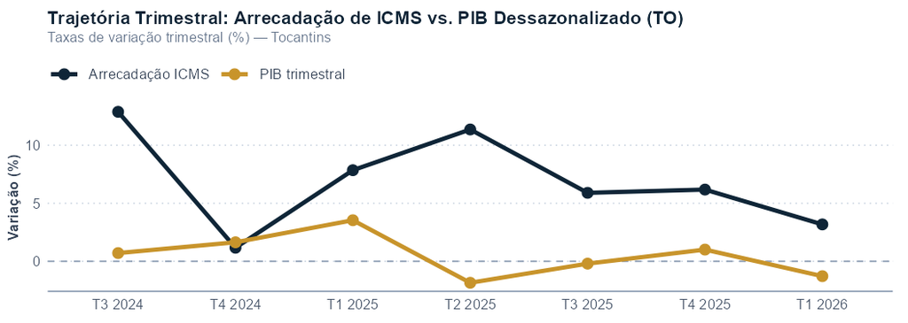

Evolução Comparada: PIB Trimestral vs. Arrecadação de ICMS (TO)

| Trimestre | PIB Trimestral Dessaz. (%) | Arrecadação ICMS (%) | Diferencial (p.p.) |
| --- | --- | --- | --- |
| T3 2024 | +0,71% | +12,88% | +12,17 p.p. |
| T4 2024 | +1,64% | +1,17% | -0,47 p.p. |
| T1 2025 | +3,54% | +7,85% | +4,31 p.p. |
| T2 2025 | -1,85% | +11,36% | +13,21 p.p. |
| T3 2025 | -0,20% | +5,90% | +6,10 p.p. |
| T4 2025 | +1,01% | +6,18% | +5,17 p.p. |
| T1 2026 | -1,28% | +3,18% | +4,46 p.p. |

Fonte: SEPLAN-TO e SEFAZ-TO.

02. Análise de Conjuntura e Leitura Setorial

A leitura conjunta dos quatro indicadores-síntese do painel revela um quadro de resiliência do ciclo doméstico tocantinense na passagem entre períodos subsequentes. Embora a variação trimestral dessazonalizada do PIB reflita a acomodação natural da safra agrícola após o pico de colheita, os indicadores mensais de alta frequência — especialmente a abertura de novos CNPJs e o fluxo de contratações formais — seguem operando acima da linha de base histórica.

03. Perspectivas e Cenários

Para os próximos meses, a sazonalidade de final de ano no comércio varejista e nos serviços pessoais tende a impulsionar tanto a arrecadação própria de ICMS quanto as contratações temporárias e efetivas no setor terciário estadual.

**Versão para impressão:** Baixe esta edição completa diagramada em PDF.Baixar Edição em PDF ↓

Boletim Flash · Boletim Flash — Dinâmica Empresarial · Outubro/2026

Baixar em PDF ↓

## Boletim Flash — Dinâmica Empresarial, Simples Nacional e Quadro Societário (QSA)

Evolução mensal do estoque de CNPJs ativos, participação de MEIs e Microempresas, tempos do Mapa de Empresas e perfil dos sócios no Tocantins

**Por Tarcisio Iago** · Economista

Economista no Jornal Econômico do Tocantins (JET). Dedica-se à análise de conjuntura regional, mercado de trabalho formal, comércio exterior e dinâmica empresarial tocantinense.

Fechamento: 14/11/2026 · Fontes Primárias: Receita Federal do Brasil / SERPRO, Portal SINAC e Mapa de Empresas (REDESIM)

**Síntese Executiva:** O Tocantins atinge 167.565 CNPJs ativos (+2.760 novas inscrições no mês), com 86,9% concentrados em MEIs e Microempresas, 164.996 optantes pelo Simples Nacional e tempo médio de abertura de 18,5 horas.

CNPJS ATIVOS (ESTOQUE)

167.565

Saldo 12m: + 15.608

MEI / MICROEMPRESAS

52,9% / 34,0%

Pequenos Negócios: 86,9%

OPTANTES SIMPLES (SINAC)

164.996

Sócios QSA: 106.471

TEMPO DE ABERTURA (2026)

18,5 horas

Viab.: 15,7h | Reg.: 2,7h

Síntese dos Indicadores no Período

- **Estoque de CNPJs Ativos (Out/2026):** Estoque de CNPJs Ativos (Out/2026) registrou aceleração expressiva de +9,65% (mudança drástica acima do padrão recente). (patamar atual: 167.565)
- **Novas Inscrições de CNPJ no Mês:** Novas Inscrições de CNPJ no Mês registrou aceleração expressiva de +5,46% (mudança drástica acima do padrão recente). (patamar atual: 2.760)
- **Participação de MEIs + Microempresas (ME):** Participação de MEIs + Microempresas (ME) manteve-se praticamente inalterado (+0,05%), indicando estabilidade marginal. (patamar atual: 86,9%)
- **Tempo Médio de Abertura de Empresas (TO vs. Brasil):** Tempo Médio de Abertura de Empresas (TO vs. Brasil) sofreu retração acentuada de -29,39% (queda drástica que requer atenção conjuntural). (patamar atual: 18,5h (BR: 26,2h))

01. Panorama Estatístico e Evidência Empírica

Em **Outubro/2026**, o Tocantins contabilizou **167.565 CNPJs ativos** (saldo líquido de **+ 15.608 empresas** em 12 meses), com **52,9%** de MEIs e **34,0%** de Microempresas (ME). O Quadro de Sócios e Administradores (QSA) reúne **106.471 vínculos societários** (167.565 empresas com responsável qualificado), enquanto o tempo médio de abertura de empresas situou-se em **18,5 horas**.

Distribuição das Empresas Ativas por Porte no Tocantins (Out/2026)

| Porte Empresarial (Receita Federal / SINAC) | CNPJs Ativos no Tocantins | Participação no Estoque (%) |
| --- | --- | --- |
| MEI | 88.650 | 52,90% |
| Microempresa (ME) | 56.958 | 33,99% |
| Pequeno Porte (EPP) | 11.896 | 7,10% |
| Não Informado / Demais | 10.061 | 6,00% |

Fonte: Receita Federal / SERPRO e SINAC.

Quadro de Sócios e Administradores (QSA) por Qualificação (Total: 106.471)

| Qualificação Legal e Tipo no QSA | Sócios Ativos | Empresas Ativas | Participação (%) |
| --- | --- | --- | --- |
| Sócio-Administrador (Pessoa Física) | 61.828 | 54.177 | 55,33% |
| Sócio (Pessoa Física) | 18.061 | 13.176 | 16,16% |
| Diretor (Pessoa Física) | 14.635 | 1.996 | 13,10% |
| Administrador (Pessoa Física) | 7.706 | 5.304 | 6,90% |
| Sócio (Pessoa Jurídica) | 4.789 | 3.274 | 4,29% |
| Conselheiro de Administração (Pessoa Física) | 1.854 | 515 | 1,66% |

Fonte: Receita Federal / SERPRO.

Perfil Demográfico Etário do Quadro Societário (QSA — Tocantins)

| Faixa Etária dos Sócios (QSA) | Total de Sócios Ativos | Empresas Ativas | Participação Etária (%) |
| --- | --- | --- | --- |
| Até 25 anos | 4.821 | 4.331 | 4,5% |
| Dos 26 aos 35 anos | 18.579 | 16.230 | 17,4% |
| Dos 36 aos 49 anos | 42.435 | 30.040 | 39,9% |
| Dos 50+ | 40.635 | 24.007 | 38,2% |

Fonte: Receita Federal / SERPRO.

02. Análise de Conjuntura e Leitura Setorial

Os dados atualizados da Receita Federal do Brasil e do SERPRO apontam continuidade na expansão da base empresarial ativa no Tocantins, que alcançou 167.565 estabelecimentos em outubro de 2026. Na passagem mensal, as 2.760 novas inscrições superaram com folga as baixas cadastrais, mantendo a trajetória de crescimento monotônico do estoque estadual.

03. Perspectivas e Cenários

A agilidade do ambiente de registro mercantil estadual — com tempo médio de abertura de 18,5 horas em 2026 contra 26,2 horas da média nacional — permanece como diferencial competitivo para a formalização de pequenos negócios no Estado.

**Versão para impressão:** Baixe esta edição completa diagramada em PDF.Baixar Edição em PDF ↓

Dossiê Anual · Dossiê Anual — Mercado de Trabalho Formal e PNAD · Balanço Anual / 12 Meses (2025–2026)

Baixar em PDF ↓

## Dossiê Anual — Mercado de Trabalho Formal (RAIS e Novo CAGED) e PNAD nas 27 UFs

Avaliação em perspectiva de 12 meses do estoque de vínculos ativos sem abandonados (RAIS), saldo acumulado de vagas (Novo CAGED), Top 5 municípios e ranking nacional de desocupação (Tabela 4099 IBGE)

**Por Tarcisio Iago** · Economista

Economista no Jornal Econômico do Tocantins (JET). Dedica-se à análise de conjuntura regional, mercado de trabalho formal, comércio exterior e dinâmica empresarial tocantinense.

Fechamento: 14/11/2026 · Fontes Primárias: MTE (Microdados Novo CAGED e RAIS) e IBGE/SIDRA (PNAD Contínua Tabelas 4099 e 5436)

**Síntese Executiva:** Com 437.580 vínculos formais ativos na RAIS (em 33.198 estabelecimentos), remuneração média de R$ 4.022,93 e taxa de desocupação de apenas 4,1% na PNAD Contínua, o Tocantins consolida uma das melhores trajetórias laborais do país em 12 meses.

ESTOQUE RAIS (2025)

437.580

Estab. Ativos: 33.198

SALDO CAGED (09/26)

+716

Adm: 11.263 | Desl: 10.547

DESOCUPAÇÃO (PNAD)

4,1%

IBGE Tabela 4099 (27 UFs)

REMUNERAÇÃO RAIS / PNAD

R$ 4.022,93

PNAD Habitual: R$ 3.351

Síntese dos Indicadores — Balanço em 12 Meses

- **Saldo Mensal do Novo CAGED (09/26):** Saldo Mensal do Novo CAGED (09/26) sofreu retração acentuada de -42,40% (queda drástica que requer atenção conjuntural). (patamar atual: +716 vagas)
- **Estoque de Vínculos Ativos (RAIS):** Estoque de Vínculos Ativos (RAIS) apresentou crescimento robusto de +5,40% no período. (patamar atual: 437.580)
- **Taxa de Desocupação PNAD (Tocantins):** Taxa de Desocupação PNAD (Tocantins) apresentou acomodação negativa de -0,30%. (patamar atual: 4,1%)
- **Rendimento Médio Real Habitual (PNAD):** Rendimento Médio Real Habitual (PNAD) avançou +4,20% em trajetória de expansão gradual. (patamar atual: R$ 3.351)

01. Panorama Estatístico e Evidência Empírica

Em **Setembro/2026**, o Tocantins gerou saldo líquido de **+716 empregos formais** no Novo CAGED (11.263 admissões e 10.547 desligamentos), sobre uma base de **437.580 vínculos ativos** na RAIS 2025. Na PNAD Contínua (Tabela 4099 do IBGE), a taxa de desocupação estadual posicionou-se em **4,1%**, com rendimento médio real habitual de **R$ 3.351**.

Movimentação Setorial do Novo CAGED no Tocantins (Setembro/2026)

| Grande Grupamento Setorial | Admissões | Desligamentos | Saldo Mês | Saldo Acum. Ano | Salário Médio Adm. |
| --- | --- | --- | --- | --- | --- |
| Serviços | 4.735 | 4.145 | +590 | +2.634 | R$ 2.055,59 |
| Construção | 1.212 | 1.001 | +211 | +2.229 | R$ 2.531,37 |
| Comércio | 3.033 | 2.912 | +121 | +329 | R$ 1.900,07 |
| Agropecuária | 1.179 | 1.366 | -187 | -851 | R$ 2.438,64 |
| Indústria | 1.104 | 1.123 | -19 | +788 | R$ 2.172,38 |

Fonte: MTE — Novo CAGED.

Top 5 Municípios do Tocantins em Estoque Formal (RAIS) e Saldo Mensal (Novo CAGED)

| Pos. | Município (Top 5 TO) | Estoque (RAIS) 2025 | Saldo (Novo CAGED) 09/26 |
| --- | --- | --- | --- |
| 1º | Palmas | 220.673 | +399 |
| 2º | Araguaína | 47.010 | +180 |
| 3º | Gurupi | 20.492 | +89 |
| 4º | Porto Nacional | 14.172 | +76 |
| 5º | Paraíso do Tocantins | 12.288 | +27 |

Fonte: MTE — RAIS e Novo CAGED.

PNAD Contínua (IBGE - Tabela 4099): Ranking Completo das 27 UFs e Brasil

| Pos. | Unidade da Federação | Taxa | Var. | Pos. | Unidade da Federação | Taxa | Var. |
| --- | --- | --- | --- | --- | --- | --- | --- |
| 1º | Santa Catarina | 2,1% | -0.1 p.p. (12m) | 15º | Maranhão | 6,0% | -0.6 p.p. (12m) |
| 2º | Mato Grosso | 2,2% | -0.6 p.p. (12m) | 16º | Pará | 6,2% | -0.7 p.p. (12m) |
| 3º | Espírito Santo | 2,3% | -0.8 p.p. (12m) | 17º | Distrito Federal | 6,5% | -2.2 p.p. (12m) |
| 4º | Rondônia | 2,6% | +0.3 p.p. (12m) | 18º | Acre | 6,6% | -0.7 p.p. (12m) |
| 5º | Mato Grosso do Sul | 2,7% | -0.2 p.p. (12m) | 19º | Ceará | 6,6% | +0.0 p.p. (12m) |
| 6º | Paraná | 3,1% | -0.7 p.p. (12m) | 20º | Rio de Janeiro | 7,1% | -1.0 p.p. (12m) |
| 7º | Minas Gerais | 3,8% | -0.2 p.p. (12m) | 21º | Amazonas | 7,5% | -0.2 p.p. (12m) |
| 8º | Goiás | 4,0% | -0.4 p.p. (12m) | 22º | Alagoas | 7,9% | +0.4 p.p. (12m) |
| 9º | * Tocantins (TO) | 4,1% | -1.2 p.p. (12m) | 23º | Sergipe | 7,9% | -0.2 p.p. (12m) |
| 10º | Rio Grande do Sul | 4,2% | -0.1 p.p. (12m) | 24º | Piauí | 8,3% | -0.2 p.p. (12m) |
| 11º | Roraima | 5,0% | -0.9 p.p. (12m) | 25º | Pernambuco | 8,3% | -2.1 p.p. (12m) |
| 12º | Paraíba | 5,4% | -1.6 p.p. (12m) | 26º | Bahia | 9,1% | +0.0 p.p. (12m) |
| 13º | São Paulo | 5,4% | +0.3 p.p. (12m) | 27º | Amapá | 9,8% | +2.9 p.p. (12m) |
| 14º | Rio Grande do Norte | 5,6% | -1.9 p.p. (12m) | BR | Brasil | 5,4% | -0.4 p.p. (12m) |

Fonte: IBGE — PNAD Contínua Trimestral (Tabela 4099).

Estrutura Anual do Emprego Formal por Escolaridade (RAIS 2025)

| Grau de Instrução (RAIS) | Estoque de Vínculos Ativos | Participação (%) | Remuneração Média (R$) |
| --- | --- | --- | --- |
| Fundamental Incompleto ou Menos | 31.898 | 7,3% | R$ 2.229,08 |
| Fundamental Completo | 14.612 | 3,3% | R$ 2.613,98 |
| Médio Incompleto | 17.220 | 3,9% | R$ 2.166,08 |
| Médio Completo | 214.334 | 49,0% | R$ 2.727,29 |
| Superior Incompleto | 8.281 | 1,9% | R$ 2.869,54 |
| Superior Completo ou Pós-Graduação | 151.235 | 34,6% | R$ 7.015,30 |

Fonte: MTE — RAIS.

Trajetória nos Últimos 12 Meses do Emprego Formal (Novo CAGED)

| Competência | Admissões Consolidadas | Desligamentos Consolidados | Saldo Líquido | Salário Médio Adm. |
| --- | --- | --- | --- | --- |
| 10/25 | 11.729 | 11.702 | +27 | R$ 1.973,31 |
| 11/25 | 9.774 | 10.137 | -363 | R$ 1.986,90 |
| 12/25 | 7.739 | 12.188 | -4.449 | R$ 1.985,61 |
| 01/26 | 12.090 | 10.505 | +1.585 | R$ 2.124,62 |
| 02/26 | 12.495 | 11.112 | +1.383 | R$ 2.066,93 |
| 03/26 | 12.262 | 11.595 | +667 | R$ 2.042,92 |
| 04/26 | 11.746 | 11.149 | +597 | R$ 2.082,84 |
| 05/26 | 11.014 | 11.650 | -636 | R$ 2.100,71 |
| 06/26 | 11.299 | 11.401 | -102 | R$ 2.109,84 |
| 07/26 | 11.794 | 12.118 | -324 | R$ 2.092,34 |
| 08/26 | 12.610 | 11.367 | +1.243 | R$ 2.076,50 |
| 09/26 | 11.263 | 10.547 | +716 | R$ 2.117,32 |

Fonte: MTE — Novo CAGED.

02. Análise de Conjuntura e Leitura Setorial

A análise anualizada do mercado de trabalho tocantinense — integrando o estoque estrutural da RAIS (depurado de vínculos abandonados em 31/12), o fluxo acumulado em 12 meses do Novo CAGED e a série trimestral da PNAD Contínua (Tabela 4099 do IBGE para todas as 27 Unidades da Federação e Brasil) — revela um processo consistente de formalização e qualificação da força de trabalho estadual.

O perfil educacional dos vínculos ativos na RAIS mostra que trabalhadores com Ensino Médio Completo e Ensino Superior Completo já respondem pela ampla maioria dos postos formais do Estado, impulsionando a remuneração média estadual para R$ 4.022,93. No recorte territorial dos cinco maiores polos empregadores (Palmas, Araguaína, Gurupi, Porto Nacional e Paraíso do Tocantins), concentra-se a tração dos setores de Serviços, Comércio e Construção Civil.

03. Perspectivas e Cenários

A manutenção da taxa de desocupação próxima ao pleno emprego friccional tende a sustentar ganhos reais de rendimento habitual no setor de serviços e exigir investimentos crescentes das empresas em treinamento técnico e retenção de talentos.

**Versão para impressão:** Baixe esta edição completa diagramada em PDF.Baixar Edição em PDF ↓

Dossiê Anual · Dossiê Anual — PIB e Contas Regionais · Consolidado Anual / Últimos 4 Trimestres (2025–2026)

Baixar em PDF ↓

## Dossiê Anual — PIB do Tocantins, Séries Dessazonalizadas e Contas Regionais

Balanço estrutural sob a ótica acumulada em 4 trimestres e plurianual: comparação entre o ajuste sazonal X-13ARIMA-SEATS (TO), a Tabela 1621 do IBGE (Brasil) e o PIB Municipal (Tabela 5938)

**Por Lorenzo Costa** · Graduado em Economia

Graduado em Economia pela UFT e editor do Jornal Econômico do Tocantins (JET). Atua na análise macroeconômica, dessazonalização de séries temporais e inteligência de dados econômicos.

Fechamento: 14/11/2026 · Fontes Primárias: SEPLAN-TO (X-13ARIMA-SEATS) e IBGE/SIDRA (Tabelas 1621, 1846, 5932 e 5938)

**Síntese Executiva:** Sob a ótica anualizada de quatro trimestres e das Contas Regionais do IBGE (Tabela 5938), o Tocantins sustenta ganho consistente de participação na Região Norte e no Brasil, combinando pujança primária com densificação industrial e de serviços nos dez maiores municípios.

PIB NOMINAL (TOCANTINS)

R$ 25,8 Bi ▼ 1,3%

Ref.: T1 2026 (SEPLAN-TO)

IMPOSTOS LÍQUIDOS (TO)

R$ 2,26 Bi ▼ 0,2%

Preços Correntes e Var. Dessaz.

PIB NOMINAL (BRASIL)

R$ 3,43 Tri ▲ 0,5%

IBGE Tabelas 1846 / 5932

Desempenho Setorial (do maior crescimento ao menor)

1º Indústria

▲ + 3,1%

Maior crescimento trimestral

2º Serviços

▲ + 1,5%

Desempenho positivo na margem

3º Agropecuária

▼ - 7,2%

Retração trimestral na margem

Síntese dos Indicadores — Balanço em 12 Meses

- **PIB Trimestral do Tocantins (Ajuste Sazonal X-13):** PIB Trimestral do Tocantins (Ajuste Sazonal X-13) apresentou acomodação negativa de -1,28%. (patamar atual: R$ 25,8 Bi ▼ 1,3%)
- **PIB Trimestral do Brasil (IBGE Tabela 1621):** PIB Trimestral do Brasil (IBGE Tabela 1621) avançou +1,07% em trajetória de expansão gradual. (patamar atual: R$ 3,43 Tri ▲ 0,5%)
- **1º Setor em Desempenho (Indústria):** 1º Setor em Desempenho (Indústria) avançou +3,07% em trajetória de expansão gradual. (patamar atual: ▲ + 3,1%)
- **3º Setor em Desempenho (Agropecuária):** 3º Setor em Desempenho (Agropecuária) recuou -7,16%, sinalizando desaceleração relevante no período. (patamar atual: ▼ - 7,2%)

01. Panorama Estatístico e Evidência Empírica

O PIB Nominal do Tocantins atingiu **R$ 25,8 Bi ▼ 1,3%** no trimestre de referência (**T1 2026**), frente a **R$ 3,43 Tri ▲ 0,5%** na economia brasileira. No pareamento setorial dessazonalizado (X-13ARIMA-SEATS vs. Tabela 1621 do IBGE), liderou o desempenho estadual o setor de **Indústria (▲ + 3,1%)**, seguido por **Serviços (▲ + 1,5%)** e **Agropecuária (▼ - 7,2%)**.

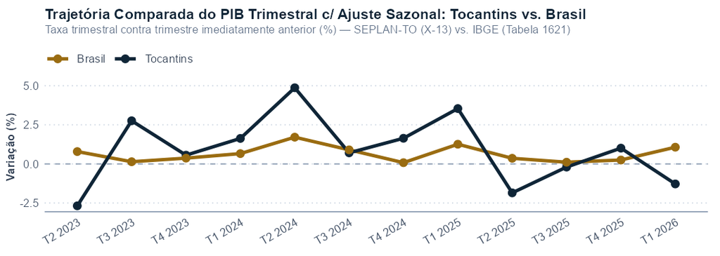

Comparativo Lado a Lado: Tocantins (X-13) vs. Brasil (Tabela 1621 IBGE)

| Trimestre | PIB TO: Índ. (Var.) | PIB BR: Índ. (Var.) | Agro TO/BR | Ind. TO/BR | Serv. TO/BR |
| --- | --- | --- | --- | --- | --- |
| T2 2024 | 173.1 (+4.87%) | 189.6 (+1.71%) | +15.4% / -1.6% | +2.2% / +0.8% | +2.4% / +1.0% |
| T3 2024 | 174.4 (+0.71%) | 191.2 (+0.90%) | -6.6% / +0.5% | -0.0% / +0.6% | +1.0% / +0.8% |
| T4 2024 | 177.2 (+1.64%) | 191.4 (+0.08%) | +17.1% / -2.2% | +0.1% / +0.3% | -0.7% / +0.0% |
| T1 2025 | 183.5 (+3.54%) | 193.8 (+1.26%) | +3.5% / +16.1% | -3.3% / +0.0% | +2.1% / +0.2% |
| T2 2025 | 180.1 (-1.85%) | 194.5 (+0.36%) | -1.1% / -3.2% | +5.9% / +0.7% | -1.1% / +0.8% |
| T3 2025 | 179.7 (-0.20%) | 194.7 (+0.11%) | -4.6% / +0.5% | -0.7% / +0.6% | +0.5% / +0.3% |
| T4 2025 | 181.6 (+1.01%) | 195.2 (+0.25%) | +6.5% / +0.7% | -3.3% / -0.7% | +1.4% / +0.6% |
| T1 2026 | 179.2 (-1.28%) | 197.3 (+1.07%) | -7.2% / +2.2% | +3.1% / +1.2% | +1.5% / +0.4% |

Fonte: SEPLAN-TO e IBGE/SIDRA (Tabela 1621).

Contas Regionais do Brasil (IBGE - Tabela 5938): PIB e Valor Adicionado do Tocantins

| Ano | PIB (R$ Mi) | Impostos (R$ Mi) | VA Agro (R$ Mi) | VA Ind. (R$ Mi) | VA Serv. (R$ Mi) | Part. Norte / BR |
| --- | --- | --- | --- | --- | --- | --- |
| 2018 | R$ 35.666,2 | R$ 3.554,2 | R$ 4.192,2 | R$ 3.942,5 | R$ 23.977,2 | 9.20% / 0.51% |
| 2019 | R$ 39.355,9 | R$ 3.817,5 | R$ 5.036,9 | R$ 4.211,5 | R$ 26.290,1 | 9.36% / 0.53% |
| 2020 | R$ 43.649,8 | R$ 4.140,9 | R$ 8.033,2 | R$ 4.408,4 | R$ 27.067,3 | 9.13% / 0.57% |
| 2021 | R$ 51.780,8 | R$ 5.085,4 | R$ 13.364,4 | R$ 5.000,3 | R$ 28.330,7 | 9.18% / 0.57% |
| 2022 | R$ 58.208,8 | R$ - | R$ - | R$ - | R$ - | 10.13% / 0.58% |
| 2023 | R$ 64.317,7 | R$ - | R$ - | R$ - | R$ - | 10.10% / 0.59% |

Fonte: IBGE — Contas Regionais do Brasil (Tabela 5938).

Ótica Anualizada (Acumulado em 4 Trimestres — SEPLAN-TO)

| Trimestre | Agropecuária | Indústria | Serviços | VA Total | Impostos | PIB Acum. 4 Trim. |
| --- | --- | --- | --- | --- | --- | --- |
| T4 2024 | +9.77% | +8.52% | +6.01% | +7.22% | +6.09% | +7.11% |
| T1 2025 | +24.92% | +5.80% | +5.30% | +10.21% | +5.79% | +9.79% |
| T2 2025 | +19.62% | +4.08% | +4.36% | +8.30% | +4.69% | +7.96% |
| T3 2025 | +21.75% | +2.50% | +2.44% | +7.24% | +2.88% | +6.83% |
| T4 2025 | +19.60% | +0.43% | +1.82% | +5.87% | +2.34% | +5.54% |
| T1 2026 | +2.72% | +1.90% | +1.72% | +1.53% | +1.81% | +1.55% |

Fonte: SEPLAN-TO.

Top 10 Municípios do Tocantins no PIB Municipal (Tabela 5938 IBGE)

| Pos. | Município do Tocantins | Ano Ref. | PIB a Preços Correntes | Participação no PIB-TO |
| --- | --- | --- | --- | --- |
| 1º | Palmas | 2023 | R$ 14.168,47 Mi | 22,03% |
| 2º | Araguaína | 2023 | R$ 7.357,64 Mi | 11,44% |
| 3º | Gurupi | 2023 | R$ 3.695,02 Mi | 5,74% |
| 4º | Porto Nacional | 2023 | R$ 3.195,89 Mi | 4,97% |
| 5º | Paraíso do Tocantins | 2023 | R$ 2.288,33 Mi | 3,56% |
| 6º | Colinas do Tocantins | 2023 | R$ 1.161,30 Mi | 1,81% |
| 7º | Guaraí | 2023 | R$ 1.130,11 Mi | 1,76% |
| 8º | Pedro Afonso | 2023 | R$ 1.090,44 Mi | 1,70% |
| 9º | Lagoa da Confusão | 2023 | R$ 1.089,84 Mi | 1,69% |
| 10º | Cariri do Tocantins | 2023 | R$ 997,80 Mi | 1,55% |

Fonte: IBGE — PIB dos Municípios.

02. Análise de Conjuntura e Leitura Setorial

Nas Contas Regionais do Brasil (Tabela 5938 do IBGE), observa-se a consolidação de uma rede urbana policêntrica: Palmas lidera a geração de Valor Adicionado em serviços e administração pública, enquanto Araguaína, Porto Nacional, Gurupi e Paraíso do Tocantins ancoram o processamento agroindustrial, o comércio atacadista e os corredores multimodais da Ferrovia Norte-Sul e da BR-153.

03. Perspectivas e Cenários

Para o horizonte plurianual, a maturação de investimentos em armazenagem, esmagamento de grãos e plantas frigoríficas aponta para a elevação da retenção interna de Valor Adicionado Industrial no território tocantinense.

**Versão para impressão:** Baixe esta edição completa diagramada em PDF.Baixar Edição em PDF ↓

Dossiê Anual · Dossiê Anual — Arrecadação e Finanças Públicas · Acumulado no Exercício e Série Plurianual (2023–2026)

Baixar em PDF ↓

## Dossiê Anual — Arrecadação Tributária e Finanças Públicas do Tocantins (2023–2026)

Análise acumulada de 12 meses e plurianual das receitas próprias (ICMS, IPVA e outros tributos) e das transferências constitucionais do FPE

**Por Lorenzo Costa** · Graduado em Economia

Graduado em Economia pela UFT e editor do Jornal Econômico do Tocantins (JET). Atua na análise macroeconômica, dessazonalização de séries temporais e inteligência de dados econômicos.

Fechamento: 14/11/2026 · Fontes Primárias: SEFAZ-TO, CONFAZ e Secretaria do Tesouro Nacional (STN)

RECEITA TOTAL DO MÊS

R$ 1,19 Bi

Ref.: 09/26

ARRECADAÇÃO DE ICMS

R$ 566,48 Mi

Var. Mês: -5,25% | YoY: +1.1%

REPASSES DO FPE

R$ 438,14 Mi

Tesouro Nacional / STN

IPVA E OUTROS TRIBUTOS

R$ 189,35 Mi

IPVA puro: R$ 53,89 Mi

Síntese dos Indicadores — Balanço em 12 Meses

- **Arrecadação de ICMS (09/26):** Arrecadação de ICMS (09/26) sofreu retração acentuada de -5,25% (queda drástica que requer atenção conjuntural). (patamar atual: R$ 566,48 Mi)
- **Cota-Parte do FPE (Transferência União):** Cota-Parte do FPE (Transferência União) sofreu retração acentuada de -19,32% (queda drástica que requer atenção conjuntural). (patamar atual: R$ 438,14 Mi)
- **IPVA e Outros Tributos Estaduais:** IPVA e Outros Tributos Estaduais sofreu retração acentuada de -10,32% (queda drástica que requer atenção conjuntural). (patamar atual: R$ 189,35 Mi)
- **Variação Interanual do ICMS (YoY):** Variação Interanual do ICMS (YoY) avançou +1,14% em trajetória de expansão gradual. (patamar atual: +1.1%)

01. Panorama Estatístico e Evidência Empírica

Na competência **Setembro/2026**, a receita total monitorada no Tocantins somou **R$ 1,19 Bi**, sendo **R$ 566,48 Mi** de arrecadação própria de ICMS (-5,25% ante o mês imediatamente anterior e +1.1% na comparação anual), **R$ 438,14 Mi** de repasses do FPE e **R$ 189,35 Mi** de IPVA e demais tributos.

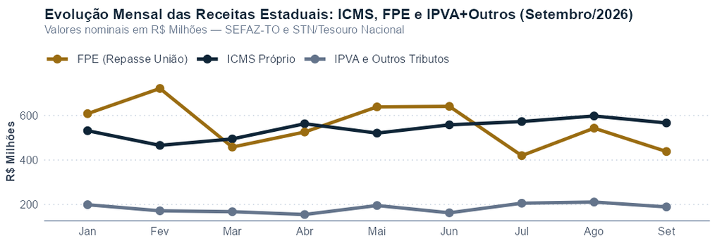

Execução Mensal das Receitas Próprias e Transferências Constitucionais (TO)

| Mês (2026) | ICMS (SEFAZ-TO) | Cota-Parte FPE (STN) | IPVA + Outros Tributos | Receita Total Mensal |
| --- | --- | --- | --- | --- |
| Jan | R$ 531,60 Mi | R$ 608,22 Mi | R$ 199,28 Mi | R$ 1.339,10 Mi |
| Fev | R$ 465,76 Mi | R$ 721,45 Mi | R$ 171,72 Mi | R$ 1.358,93 Mi |
| Mar | R$ 494,71 Mi | R$ 458,07 Mi | R$ 167,87 Mi | R$ 1.120,65 Mi |
| Abr | R$ 562,91 Mi | R$ 525,78 Mi | R$ 155,18 Mi | R$ 1.243,87 Mi |
| Mai | R$ 520,81 Mi | R$ 638,69 Mi | R$ 195,65 Mi | R$ 1.355,15 Mi |
| Jun | R$ 557,93 Mi | R$ 640,98 Mi | R$ 162,83 Mi | R$ 1.361,74 Mi |
| Jul | R$ 572,89 Mi | R$ 419,66 Mi | R$ 206,02 Mi | R$ 1.198,57 Mi |
| Ago | R$ 597,87 Mi | R$ 543,05 Mi | R$ 211,15 Mi | R$ 1.352,07 Mi |
| Set | R$ 566,48 Mi | R$ 438,14 Mi | R$ 189,35 Mi | R$ 1.193,97 Mi |

Fonte: SEFAZ-TO e STN.

Arrecadação de ICMS por Segmento Econômico (Setembro/2026)

| Segmento Econômico do ICMS (Painel) | Arrecadação no Mês | Participação no ICMS (%) |
| --- | --- | --- |
| Combustíveis | R$ 172,81 Mi | 30,51% |
| Comércio | R$ 172,77 Mi | 30,50% |
| Indústria | R$ 103,08 Mi | 18,20% |
| Energia Elétrica | R$ 63,73 Mi | 11,25% |
| Demais Atividades | R$ 30,11 Mi | 5,32% |
| Comunicação | R$ 9,20 Mi | 1,62% |
| Transportes | R$ 8,27 Mi | 1,46% |
| Agropecuária | R$ 6,52 Mi | 1,15% |

Fonte: SEFAZ-TO.

Consolidado Plurianual das Receitas Estaduais (2023–2026)

| Exercício | Receita Total | ICMS Acumulado | FPE Acumulado | IPVA + Outros | Var. Anual ICMS |
| --- | --- | --- | --- | --- | --- |
| 2023 (Jan-Dez) | R$ 12.120,0 Mi | R$ 5.028,9 Mi | R$ 5.238,3 Mi | R$ 2.368,4 Mi | - |
| 2024 (Jan-Dez) | R$ 13.756,3 Mi | R$ 5.949,4 Mi | R$ 5.744,1 Mi | R$ 2.623,4 Mi | +18.31% |
| 2025 (Jan-Dez) | R$ 14.940,0 Mi | R$ 6.407,9 Mi | R$ 6.228,3 Mi | R$ 2.913,3 Mi | +7.71% |
| 2026 (Acum. Jan-Set) | R$ 11.522,1 Mi | R$ 4.871,0 Mi | R$ 4.994,0 Mi | R$ 2.023,6 Mi | +3.65% |

Fonte: SEFAZ-TO e STN.

02. Análise de Conjuntura e Leitura Setorial

A composição setorial do ICMS evidencia que Combustíveis, Comércio e Indústria respondem por mais de 78% da arrecadação própria estadual, funcionando como termômetro direto da circulação de mercadorias no corredor logístico Norte-Sul e do consumo das famílias nos municípios polos.

03. Perspectivas e Cenários

Para o fechamento do exercício fiscal, o ingresso sazonal das receitas de fim de ano e a estabilidade da base de contribuintes ativos apontam para o cumprimento confortável das metas arrecadatórias estaduais.

**Versão para impressão:** Baixe esta edição completa diagramada em PDF.Baixar Edição em PDF ↓

Dossiê Anual · Dossiê Anual — Dinâmica Empresarial e QSA · Acumulado em 12 Meses (Novembro/2025 a Outubro/2026)

Baixar em PDF ↓

## Dossiê Anual — Demografia Empresarial, Simples Nacional e Quadro Societário (QSA)

Balanço de 12 meses das aberturas, baixas e estoque de CNPJs ativos por porte (MEI, ME e EPP), adesão ao Simples Nacional, perfil societário (QSA) e eficiência da REDESIM no Tocantins

**Por Lorenzo Costa** · Graduado em Economia

Graduado em Economia pela UFT e editor do Jornal Econômico do Tocantins (JET). Atua na análise macroeconômica, dessazonalização de séries temporais e inteligência de dados econômicos.

Fechamento: 14/11/2026 · Fontes Primárias: Receita Federal do Brasil / SERPRO, Portal SINAC e Mapa de Empresas (REDESIM)

CNPJS ATIVOS (ESTOQUE)

167.565

Saldo 12m: + 15.608

MEI / MICROEMPRESAS

52,9% / 34,0%

Pequenos Negócios: 86,9%

OPTANTES SIMPLES (SINAC)

164.996

Sócios QSA: 106.471

TEMPO DE ABERTURA (2026)

18,5 horas

Viab.: 15,7h | Reg.: 2,7h

Síntese dos Indicadores — Balanço em 12 Meses

- **Estoque de CNPJs Ativos (Out/2026):** Estoque de CNPJs Ativos (Out/2026) registrou aceleração expressiva de +9,65% (mudança drástica acima do padrão recente). (patamar atual: 167.565)
- **Novas Inscrições de CNPJ no Mês:** Novas Inscrições de CNPJ no Mês registrou aceleração expressiva de +5,46% (mudança drástica acima do padrão recente). (patamar atual: 2.760)
- **Participação de MEIs + Microempresas (ME):** Participação de MEIs + Microempresas (ME) manteve-se praticamente inalterado (+0,05%), indicando estabilidade marginal. (patamar atual: 86,9%)
- **Tempo Médio de Abertura de Empresas (TO vs. Brasil):** Tempo Médio de Abertura de Empresas (TO vs. Brasil) sofreu retração acentuada de -29,39% (queda drástica que requer atenção conjuntural). (patamar atual: 18,5h (BR: 26,2h))

01. Panorama Estatístico e Evidência Empírica

Em **Outubro/2026**, o Tocantins contabilizou **167.565 CNPJs ativos** (saldo líquido de **+ 15.608 empresas** em 12 meses), com **52,9%** de MEIs e **34,0%** de Microempresas (ME). O Quadro de Sócios e Administradores (QSA) reúne **106.471 vínculos societários** (167.565 empresas com responsável qualificado), enquanto o tempo médio de abertura de empresas situou-se em **18,5 horas**.

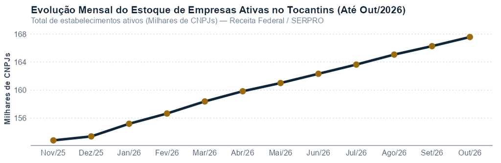

Distribuição das Empresas Ativas por Porte no Tocantins (Out/2026)

| Porte Empresarial (Receita Federal / SINAC) | CNPJs Ativos no Tocantins | Participação no Estoque (%) |
| --- | --- | --- |
| MEI | 88.650 | 52,90% |
| Microempresa (ME) | 56.958 | 33,99% |
| Pequeno Porte (EPP) | 11.896 | 7,10% |
| Não Informado / Demais | 10.061 | 6,00% |

Fonte: Receita Federal / SERPRO e SINAC.

Quadro de Sócios e Administradores (QSA) por Qualificação (Total: 106.471)

| Qualificação Legal e Tipo no QSA | Sócios Ativos | Empresas Ativas | Participação (%) |
| --- | --- | --- | --- |
| Sócio-Administrador (Pessoa Física) | 61.828 | 54.177 | 55,33% |
| Sócio (Pessoa Física) | 18.061 | 13.176 | 16,16% |
| Diretor (Pessoa Física) | 14.635 | 1.996 | 13,10% |
| Administrador (Pessoa Física) | 7.706 | 5.304 | 6,90% |
| Sócio (Pessoa Jurídica) | 4.789 | 3.274 | 4,29% |
| Conselheiro de Administração (Pessoa Física) | 1.854 | 515 | 1,66% |

Fonte: Receita Federal / SERPRO.

Perfil Demográfico Etário do Quadro Societário (QSA — Tocantins)

| Faixa Etária dos Sócios (QSA) | Total de Sócios Ativos | Empresas Ativas | Participação Etária (%) |
| --- | --- | --- | --- |
| Até 25 anos | 4.821 | 4.331 | 4,5% |
| Dos 26 aos 35 anos | 18.579 | 16.230 | 17,4% |
| Dos 36 aos 49 anos | 42.435 | 30.040 | 39,9% |
| Dos 50+ | 40.635 | 24.007 | 38,2% |

Fonte: Receita Federal / SERPRO.

Balanço Demográfico Empresarial nos Últimos 12 Meses (TO)

| Competência | Novas Inscrições (Aberturas) | Baixas / Extinções | Saldo Líquido Mensal | Estoque de CNPJs Ativos |
| --- | --- | --- | --- | --- |
| Nov/25 | 2.168 | 1.306 | +862 | 152.819 |
| Dez/25 | 2.007 | 1.441 | +566 | 153.385 |
| Jan/26 | 3.845 | 2.042 | +1.803 | 155.188 |
| Fev/26 | 3.241 | 1.781 | +1.460 | 156.648 |
| Mar/26 | 3.518 | 1.790 | +1.728 | 158.376 |
| Abr/26 | 3.086 | 1.636 | +1.450 | 159.826 |
| Mai/26 | 2.973 | 1.798 | +1.175 | 161.001 |
| Jun/26 | 3.009 | 1.690 | +1.319 | 162.320 |
| Jul/26 | 2.781 | 1.468 | +1.313 | 163.633 |
| Ago/26 | 2.989 | 1.562 | +1.427 | 165.060 |
| Set/26 | 2.617 | 1.416 | +1.201 | 166.261 |
| Out/26 | 2.760 | 1.456 | +1.304 | 167.565 |

Fonte: Receita Federal / SERPRO.

02. Análise de Conjuntura e Leitura Setorial

03. Perspectivas e Cenários

A consolidação do tempo médio de abertura em 18,5 horas no Mapa de Empresas (REDESIM) e a elevada adesão ao Simples Nacional (164.996 optantes) projetam continuidade do ciclo de formalização empresarial ao longo do próximo exercício.

**Versão para impressão:** Baixe esta edição completa diagramada em PDF.Baixar Edição em PDF ↓

Boletim Flash · Boletim Flash — Arrecadação e Finanças · Outubro/2026

Baixar em PDF ↓

Receita própria estadual ganha tração e equilibra a composição fiscal ao lado das transferências federais do FPE

**Por Lorenzo Costa** · Graduado em Economia

Graduado em Economia pela UFT e editor do Jornal Econômico do Tocantins (JET). Atua na análise macroeconômica, dessazonalização de séries temporais e inteligência de dados econômicos.

Fechamento: 29/10/2026 · Fontes Primárias: SEFAZ-TO, CONFAZ e Secretaria do Tesouro Nacional (STN)

**Síntese Executiva:** O desempenho positivo da arrecadação tributária própria reflete o maior giro mercantil no corredor logístico da BR-153 e a expansão do consumo interno no Estado.

RECEITA TOTAL DO MÊS

R$ 1,19 Bi

Ref.: 09/26

ARRECADAÇÃO DE ICMS

R$ 566,48 Mi

Var. Mês: -5,25% | YoY: +1.1%

REPASSES DO FPE

R$ 438,14 Mi

Tesouro Nacional / STN

IPVA E OUTROS TRIBUTOS

R$ 189,35 Mi

IPVA puro: R$ 53,89 Mi

Síntese dos Indicadores no Período

- **Arrecadação de ICMS (09/26):** Arrecadação de ICMS (09/26) sofreu retração acentuada de -5,25% (queda drástica que requer atenção conjuntural). (patamar atual: R$ 566,48 Mi)
- **Cota-Parte do FPE (Transferência União):** Cota-Parte do FPE (Transferência União) sofreu retração acentuada de -19,32% (queda drástica que requer atenção conjuntural). (patamar atual: R$ 438,14 Mi)
- **IPVA e Outros Tributos Estaduais:** IPVA e Outros Tributos Estaduais sofreu retração acentuada de -10,32% (queda drástica que requer atenção conjuntural). (patamar atual: R$ 189,35 Mi)
- **Variação Interanual do ICMS (YoY):** Variação Interanual do ICMS (YoY) avançou +1,14% em trajetória de expansão gradual. (patamar atual: +1.1%)

01. Panorama Estatístico e Evidência Empírica

Na competência **Setembro/2026**, a receita total monitorada no Tocantins somou **R$ 1,19 Bi**, sendo **R$ 566,48 Mi** de arrecadação própria de ICMS (-5,25% ante o mês imediatamente anterior e +1.1% na comparação anual), **R$ 438,14 Mi** de repasses do FPE e **R$ 189,35 Mi** de IPVA e demais tributos.

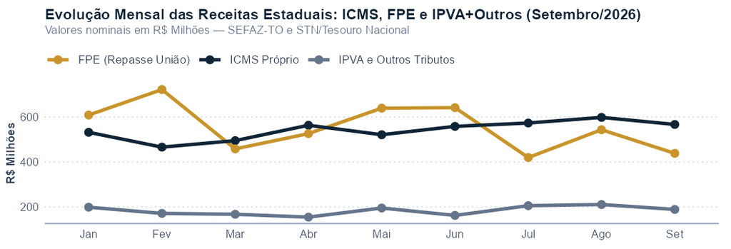

Execução Mensal das Receitas Próprias e Transferências Constitucionais (TO)

| Mês (2026) | ICMS (SEFAZ-TO) | Cota-Parte FPE (STN) | IPVA + Outros Tributos | Receita Total Mensal |
| --- | --- | --- | --- | --- |
| Jan | R$ 531,60 Mi | R$ 608,22 Mi | R$ 199,28 Mi | R$ 1.339,10 Mi |
| Fev | R$ 465,76 Mi | R$ 721,45 Mi | R$ 171,72 Mi | R$ 1.358,93 Mi |
| Mar | R$ 494,71 Mi | R$ 458,07 Mi | R$ 167,87 Mi | R$ 1.120,65 Mi |
| Abr | R$ 562,91 Mi | R$ 525,78 Mi | R$ 155,18 Mi | R$ 1.243,87 Mi |
| Mai | R$ 520,81 Mi | R$ 638,69 Mi | R$ 195,65 Mi | R$ 1.355,15 Mi |
| Jun | R$ 557,93 Mi | R$ 640,98 Mi | R$ 162,83 Mi | R$ 1.361,74 Mi |
| Jul | R$ 572,89 Mi | R$ 419,66 Mi | R$ 206,02 Mi | R$ 1.198,57 Mi |
| Ago | R$ 597,87 Mi | R$ 543,05 Mi | R$ 211,15 Mi | R$ 1.352,07 Mi |
| Set | R$ 566,48 Mi | R$ 438,14 Mi | R$ 189,35 Mi | R$ 1.193,97 Mi |

Fonte: SEFAZ-TO e STN.

Arrecadação de ICMS por Segmento Econômico (Setembro/2026)

| Segmento Econômico do ICMS (Painel) | Arrecadação no Mês | Participação no ICMS (%) |
| --- | --- | --- |
| Combustíveis | R$ 172,81 Mi | 30,51% |
| Comércio | R$ 172,77 Mi | 30,50% |
| Indústria | R$ 103,08 Mi | 18,20% |
| Energia Elétrica | R$ 63,73 Mi | 11,25% |
| Demais Atividades | R$ 30,11 Mi | 5,32% |
| Comunicação | R$ 9,20 Mi | 1,62% |
| Transportes | R$ 8,27 Mi | 1,46% |
| Agropecuária | R$ 6,52 Mi | 1,15% |

Fonte: SEFAZ-TO.

02. Análise de Conjuntura e Leitura Setorial

Ao mesmo tempo, a complementaridade entre a arrecadação própria (ICMS e IPVA) e as transferências constitucionais do Fundo de Participação dos Estados (FPE) garante previsibilidade de caixa ao Tesouro Estadual, permitindo a manutenção do cronograma de investimentos públicos em malha viária e serviços essenciais.

03. Perspectivas e Cenários

Nos próximos meses, a intensificação do transporte da safra e o aquecimento das vendas de fim de ano devem sustentar o crescimento real da receita de ICMS, ampliando o espaço fiscal para o fechamento do exercício orçamentário com equilíbrio nas contas públicas.

**Versão para impressão:** Baixe esta edição completa diagramada em PDF.Baixar Edição em PDF ↓

Boletim Flash · Boletim Flash — Comércio Exterior · Outubro/2026

Baixar em PDF ↓

## Balança comercial do Tocantins mantém superávit robusto no mês puxada pelo complexo soja e carnes

Embarques para o mercado asiático sustentam geração líquida de divisas e compensam importação de fertilizantes

**Por Tarcisio Iago** · Economista

Economista no Jornal Econômico do Tocantins (JET). Dedica-se à análise de conjuntura regional, mercado de trabalho formal, comércio exterior e dinâmica empresarial tocantinense.

Fechamento: 30/10/2026 · Fontes Primárias: Comex Stat / MDIC — Ministério do Desenvolvimento, Indústria, Comércio e Serviços

EXPORTAÇÕES (TO)

US$ 200,89 Mi

Ref.: 10/2026 (Peso: 289.390 t)

IMPORTAÇÕES (TO)

US$ 63,95 Mi

Ref.: 10/2026 (Peso: 148.241 t)

SALDO COMERCIAL

+ US$ 136,94 Mi

Superávit Primário FOB

1º DESTINO EXPORTADOR

China

23,4% da pauta (US$ 47,0 Mi)

Síntese dos Indicadores no Período

- **Exportações FOB do Tocantins (10/2026):** Exportações FOB do Tocantins (10/2026) registrou aceleração expressiva de +17,97% (mudança drástica acima do padrão recente). (patamar atual: US$ 200,89 Mi)
- **Importações FOB do Tocantins (10/2026):** Importações FOB do Tocantins (10/2026) registrou aceleração expressiva de +118,57% (mudança drástica acima do padrão recente). (patamar atual: US$ 63,95 Mi)
- **Saldo da Balança Comercial (TO):** Saldo da Balança Comercial (TO) sofreu retração acentuada de -2,91% (queda drástica que requer atenção conjuntural). (patamar atual: + US$ 136,94 Mi)
- **1º Produto Exportado (Carnes de animais da espécie bovina, congeladas):** 1º Produto Exportado (Carnes de animais da espécie bovina, congeladas) registrou aceleração expressiva de +25,03% (mudança drástica acima do padrão recente). (patamar atual: US$ 50,28 Mi)

01. Panorama Estatístico e Evidência Empírica

Na competência **10/2026**, as exportações do Tocantins somaram **US$ 200,89 Mi** (289.389,8 toneladas), ante importações de **US$ 63,95 Mi** (148.240,8 toneladas), resultando em saldo comercial de **+ US$ 136,94 Mi**.

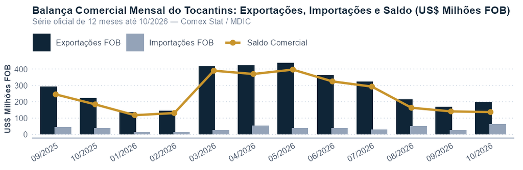

Top 10 Posições SH4 Exportadas pelo Tocantins (Mês 10/2026)

| Pos. | SH4 | Produto Exportado (Top 10) | Valor FOB | Peso Líq. (Ton) | US$/Kg | Part. % |
| --- | --- | --- | --- | --- | --- | --- |
| 1º | 0202 | Carnes de animais da espécie bovina, c | US$ 50,28 Mi | 7.887,5 t | US$ 6,37 | 25,0% |
| 2º | 1201 | Soja, mesmo triturada | US$ 36,35 Mi | 78.566,0 t | US$ 0,46 | 18,1% |
| 3º | 0713 | Legumes de vagem, secos, em grão, mesm | US$ 32,65 Mi | 38.897,1 t | US$ 0,84 | 16,2% |
| 4º | 1005 | Milho | US$ 24,22 Mi | 112.206,9 t | US$ 0,22 | 12,1% |
| 5º | 7108 | Ouro | US$ 23,48 Mi | 0,2 t | US$ 118.600,72 | 11,7% |
| 6º | 2304 | Tortas e outros resíduos sólidos da ex | US$ 15,35 Mi | 39.290,1 t | US$ 0,39 | 7,6% |
| 7º | 3504 | Peptonas e seus derivados | US$ 5,77 Mi | 792,5 t | US$ 7,28 | 2,9% |
| 8º | 0201 | Carnes de animais da espécie bovina, f | US$ 3,67 Mi | 534,1 t | US$ 6,87 | 1,8% |
| 9º | 0206 | Miudezas comestíveis de animais das es | US$ 1,91 Mi | 830,3 t | US$ 2,30 | 0,9% |
| 10º | 1007 | Sorgo de grão | US$ 1,17 Mi | 5.411,3 t | US$ 0,22 | 0,6% |

Fonte: Comex Stat / MDIC.

Top 10 Posições SH4 Importadas pelo Tocantins (Mês 10/2026)

| Pos. | SH4 | Produto Importado (Top 10) | Valor FOB | Peso Líq. (Ton) | US$/Kg | Part. % |
| --- | --- | --- | --- | --- | --- | --- |
| 1º | 3102 | Adubos (fertilizantes) azotados | US$ 34,82 Mi | 92.798,0 t | US$ 0,38 | 54,5% |
| 2º | 3104 | Adubos (fertilizantes) potássicos | US$ 5,70 Mi | 17.875,8 t | US$ 0,32 | 8,9% |
| 3º | 7210 | Produtos laminados planos de ferro ou | US$ 4,78 Mi | 5.854,2 t | US$ 0,82 | 7,5% |
| 4º | 2713 | Coque de petróleo, betume de petróleo | US$ 3,00 Mi | 17.662,4 t | US$ 0,17 | 4,7% |
| 5º | 2715 | Misturas betuminosas à base de asfalto | US$ 1,39 Mi | 2.561,6 t | US$ 0,54 | 2,2% |
| 6º | 3103 | Adubos (fertilizantes) fosfatados | US$ 1,27 Mi | 5.508,0 t | US$ 0,23 | 2,0% |
| 7º | 3808 | Insecticidas, rodenticidas, fungicidas | US$ 1,14 Mi | 309,9 t | US$ 3,69 | 1,8% |
| 8º | 2905 | Álcoois acíclicos e seus derivados hal | US$ 1,02 Mi | 2.000,0 t | US$ 0,51 | 1,6% |
| 9º | 1513 | Óleos de coco (óleo de copra), de palm | US$ 0,90 Mi | 447,1 t | US$ 2,01 | 1,4% |
| 10º | 9003 | Armações para óculos e artigos semelha | US$ 0,77 Mi | 2,7 t | US$ 286,02 | 1,2% |

Fonte: Comex Stat / MDIC.

Top 10 Países Parceiros do Tocantins (Mês 10/2026)

| Pos. | Destino Exportação (TO) | US$ FOB Exp. | % Exp. | Origem Importação (TO) | US$ FOB Imp. | % Imp. |
| --- | --- | --- | --- | --- | --- | --- |
| 1º | China | US$ 46,97 Mi | 23,4% | China | US$ 15,98 Mi | 25,0% |
| 2º | Índia | US$ 33,59 Mi | 16,7% | Nigéria | US$ 14,93 Mi | 23,3% |
| 3º | Canadá | US$ 16,57 Mi | 8,2% | Venezuela | US$ 14,67 Mi | 22,9% |
| 4º | Egito | US$ 16,18 Mi | 8,1% | Canadá | US$ 5,71 Mi | 8,9% |
| 5º | Espanha | US$ 10,32 Mi | 5,1% | Estados Unidos | US$ 4,48 Mi | 7,0% |
| 6º | Suíça | US$ 8,20 Mi | 4,1% | Vietnã | US$ 3,90 Mi | 6,1% |
| 7º | Alemanha | US$ 7,64 Mi | 3,8% | Egito | US$ 1,27 Mi | 2,0% |
| 8º | México | US$ 6,47 Mi | 3,2% | Brunei | US$ 0,92 Mi | 1,4% |
| 9º | Eslovênia | US$ 5,31 Mi | 2,6% | Indonésia | US$ 0,90 Mi | 1,4% |
| 10º | Estados Unidos | US$ 4,17 Mi | 2,1% | África do Sul | US$ 0,38 Mi | 0,6% |

Fonte: Comex Stat / MDIC.

02. Análise de Conjuntura e Leitura Setorial

O resultado mensal da balança comercial do Tocantins reforça a posição estratégica do Estado como plataforma agroexportadora da região Norte. O desempenho das vendas externas segue ancorado na competitividade da soja em grãos e da carne bovina in natura, que encontraram janelas favoráveis de embarque nos portos do Arco Norte e demanda firme dos compradores asiáticos.

03. Perspectivas e Cenários

Para os próximos meses, a expectativa é de manutenção do saldo comercial amplamente superavitário, favorecido pela taxa de câmbio em patamar competitivo em reais e pelo escoamento dos estoques estaduais de milho e proteína animal.

**Versão para impressão:** Baixe esta edição completa diagramada em PDF.Baixar Edição em PDF ↓

Boletim Flash · Boletim Flash — Mercado de Trabalho · Outubro/2026

Baixar em PDF ↓

## Mercado de trabalho formal no Tocantins mantém geração líquida positiva puxada por Serviços e Construção

Dinamismo nos polos regionais de Palmas, Araguaína e Gurupi sustenta baixa taxa de desocupação estadual

**Por Tarcisio Iago** · Economista

Economista no Jornal Econômico do Tocantins (JET). Dedica-se à análise de conjuntura regional, mercado de trabalho formal, comércio exterior e dinâmica empresarial tocantinense.

Fechamento: 29/10/2026 · Fontes Primárias: MTE (Microdados Novo CAGED e RAIS) e IBGE/SIDRA (PNAD Contínua Tabelas 4099 e 5436)

ESTOQUE RAIS (2025)

437.580

Estab. Ativos: 33.198

SALDO CAGED (09/26)

+716

Adm: 11.263 | Desl: 10.547

DESOCUPAÇÃO (PNAD)

4,1%

IBGE Tabela 4099 (27 UFs)

REMUNERAÇÃO RAIS / PNAD

R$ 4.022,93

PNAD Habitual: R$ 3.351

Síntese dos Indicadores no Período

- **Saldo Mensal do Novo CAGED (09/26):** Saldo Mensal do Novo CAGED (09/26) sofreu retração acentuada de -42,40% (queda drástica que requer atenção conjuntural). (patamar atual: +716 vagas)
- **Estoque de Vínculos Ativos (RAIS):** Estoque de Vínculos Ativos (RAIS) apresentou crescimento robusto de +5,40% no período. (patamar atual: 437.580)
- **Taxa de Desocupação PNAD (Tocantins):** Taxa de Desocupação PNAD (Tocantins) apresentou acomodação negativa de -0,30%. (patamar atual: 4,1%)
- **Rendimento Médio Real Habitual (PNAD):** Rendimento Médio Real Habitual (PNAD) avançou +4,20% em trajetória de expansão gradual. (patamar atual: R$ 3.351)

01. Panorama Estatístico e Evidência Empírica

Em **Setembro/2026**, o Tocantins gerou saldo líquido de **+716 empregos formais** no Novo CAGED (11.263 admissões e 10.547 desligamentos), sobre uma base de **437.580 vínculos ativos** na RAIS 2025. Na PNAD Contínua (Tabela 4099 do IBGE), a taxa de desocupação estadual posicionou-se em **4,1%**, com rendimento médio real habitual de **R$ 3.351**.

Movimentação Setorial do Novo CAGED no Tocantins (Setembro/2026)

| Grande Grupamento Setorial | Admissões | Desligamentos | Saldo Mês | Saldo Acum. Ano | Salário Médio Adm. |
| --- | --- | --- | --- | --- | --- |
| Serviços | 4.735 | 4.145 | +590 | +2.634 | R$ 2.055,59 |
| Construção | 1.212 | 1.001 | +211 | +2.229 | R$ 2.531,37 |
| Comércio | 3.033 | 2.912 | +121 | +329 | R$ 1.900,07 |
| Agropecuária | 1.179 | 1.366 | -187 | -851 | R$ 2.438,64 |
| Indústria | 1.104 | 1.123 | -19 | +788 | R$ 2.172,38 |

Fonte: MTE — Novo CAGED.

Top 5 Municípios do Tocantins em Estoque Formal (RAIS) e Saldo Mensal (Novo CAGED)

| Pos. | Município (Top 5 TO) | Estoque (RAIS) 2025 | Saldo (Novo CAGED) 09/26 |
| --- | --- | --- | --- |
| 1º | Palmas | 220.673 | +399 |
| 2º | Araguaína | 47.010 | +180 |
| 3º | Gurupi | 20.492 | +89 |
| 4º | Porto Nacional | 14.172 | +76 |
| 5º | Paraíso do Tocantins | 12.288 | +27 |

Fonte: MTE — RAIS e Novo CAGED.

PNAD Contínua (IBGE - Tabela 4099): Ranking Completo das 27 UFs e Brasil

| Pos. | Unidade da Federação | Taxa | Var. | Pos. | Unidade da Federação | Taxa | Var. |
| --- | --- | --- | --- | --- | --- | --- | --- |
| 1º | Santa Catarina | 2,1% | -0.6 p.p. (trim) | 15º | Maranhão | 6,0% | -0.9 p.p. (trim) |
| 2º | Mato Grosso | 2,2% | -0.9 p.p. (trim) | 16º | Pará | 6,2% | -0.8 p.p. (trim) |
| 3º | Espírito Santo | 2,3% | -0.9 p.p. (trim) | 17º | Distrito Federal | 6,5% | -0.6 p.p. (trim) |
| 4º | Rondônia | 2,6% | -1.1 p.p. (trim) | 18º | Acre | 6,6% | -1.6 p.p. (trim) |
| 5º | Mato Grosso do Sul | 2,7% | -1.1 p.p. (trim) | 19º | Ceará | 6,6% | -0.7 p.p. (trim) |
| 6º | Paraná | 3,1% | -0.4 p.p. (trim) | 20º | Rio de Janeiro | 7,1% | -0.2 p.p. (trim) |
| 7º | Minas Gerais | 3,8% | -1.2 p.p. (trim) | 21º | Amazonas | 7,5% | -0.8 p.p. (trim) |
| 8º | Goiás | 4,0% | -1.1 p.p. (trim) | 22º | Alagoas | 7,9% | -1.3 p.p. (trim) |
| 9º | * Tocantins (TO) | 4,1% | -1.5 p.p. (trim) | 23º | Sergipe | 7,9% | -0.7 p.p. (trim) |
| 10º | Rio Grande do Sul | 4,2% | +0.2 p.p. (trim) | 24º | Piauí | 8,3% | -0.6 p.p. (trim) |
| 11º | Roraima | 5,0% | -0.7 p.p. (trim) | 25º | Pernambuco | 8,3% | -0.9 p.p. (trim) |
| 12º | Paraíba | 5,4% | -1.6 p.p. (trim) | 26º | Bahia | 9,1% | -0.1 p.p. (trim) |
| 13º | São Paulo | 5,4% | -0.6 p.p. (trim) | 27º | Amapá | 9,8% | -0.2 p.p. (trim) |
| 14º | Rio Grande do Norte | 5,6% | -2.0 p.p. (trim) | BR | Brasil | 5,4% | -0.7 p.p. (trim) |

Fonte: IBGE — PNAD Contínua Trimestral (Tabela 4099).

02. Análise de Conjuntura e Leitura Setorial

O comportamento recente do mercado de trabalho formal no Tocantins reflete um ciclo virtuoso de transmissão de renda do setor primário e das obras de infraestrutura para as atividades urbanas. A liderança do setor de Serviços e da Construção Civil na abertura líquida de postos com carteira assinada evidencia que o crescimento econômico estadual não está restrito ao campo, mas transborda para o consumo das famílias e para o mercado imobiliário nas principais cidades.

A análise regionalizada dos municípios confirma o papel de Palmas, Araguaína e Gurupi como grandes absorvedores de mão de obra formal, seguidos por Porto Nacional e Paraíso do Tocantins, que se beneficiam diretamente de sua posição estratégica como entroncamentos logísticos e industriais no eixo da BR-153.

03. Perspectivas e Cenários

Para a reta final do ano, a expectativa da equipe é de manutenção de saldos positivos em outubro e novembro, impulsionados pelas contratações temporárias de fim de ano no comércio varejista e nos serviços de alimentação e logística, antes do ajuste sazonal típico do mês de dezembro.

**Versão para impressão:** Baixe esta edição completa diagramada em PDF.Baixar Edição em PDF ↓

Dossiê Anual · Dossiê Anual — Balança Comercial do Tocantins · Consolidado 2026

Baixar em PDF ↓

## Balanço Consolidado do Comércio Exterior Tocantinense: Superávit estrutural e avanço das cadeias agroindustriais

Análise integrada da pauta exportadora, dependências de insumos importados e posicionamento competitivo do Estado no mercado internacional

**Por Tarcisio Iago** · Economista

Economista no Jornal Econômico do Tocantins (JET). Dedica-se à análise de conjuntura regional, mercado de trabalho formal, comércio exterior e dinâmica empresarial tocantinense.

Fechamento: 29/10/2026 · Fontes Primárias: Comex Stat / MDIC — Ministério do Desenvolvimento, Indústria, Comércio e Serviços

EXPORTAÇÕES (TO)

US$ 200,89 Mi

Ref.: 10/2026 (Peso: 289.390 t)

IMPORTAÇÕES (TO)

US$ 63,95 Mi

Ref.: 10/2026 (Peso: 148.241 t)

SALDO COMERCIAL

+ US$ 136,94 Mi

Superávit Primário FOB

1º DESTINO EXPORTADOR

China

55,6% da pauta (US$ 1.571,4 Mi)

Síntese dos Indicadores — Balanço em 12 Meses

- **Exportações FOB do Tocantins (10/2026):** Exportações FOB do Tocantins (10/2026) registrou aceleração expressiva de +17,97% (mudança drástica acima do padrão recente). (patamar atual: US$ 200,89 Mi)
- **Importações FOB do Tocantins (10/2026):** Importações FOB do Tocantins (10/2026) registrou aceleração expressiva de +118,57% (mudança drástica acima do padrão recente). (patamar atual: US$ 63,95 Mi)
- **Saldo da Balança Comercial (TO):** Saldo da Balança Comercial (TO) sofreu retração acentuada de -2,91% (queda drástica que requer atenção conjuntural). (patamar atual: + US$ 136,94 Mi)
- **1º Produto Exportado (Soja, mesmo triturada):** 1º Produto Exportado (Soja, mesmo triturada) registrou aceleração expressiva de +54,05% (mudança drástica acima do padrão recente). (patamar atual: US$ 1.528,48 Mi)

01. Panorama Estatístico e Evidência Empírica

Na competência **10/2026**, as exportações do Tocantins somaram **US$ 200,89 Mi** (289.389,8 toneladas), ante importações de **US$ 63,95 Mi** (148.240,8 toneladas), resultando em saldo comercial de **+ US$ 136,94 Mi**.

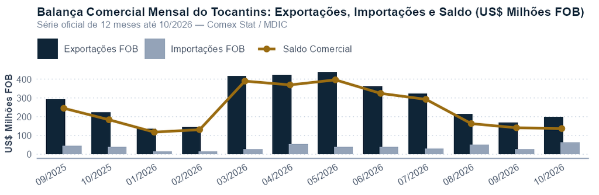

Top 10 Posições SH4 Exportadas pelo Tocantins (Acumulado no Ano até 10/2026)

| Pos. | SH4 | Produto Exportado (Top 10) | Valor FOB | Peso Líq. (Ton) | US$/Kg | Part. % |
| --- | --- | --- | --- | --- | --- | --- |
| 1º | 1201 | Soja, mesmo triturada | US$ 1.528,48 Mi | 3.647.173,2 t | US$ 0,42 | 54,0% |
| 2º | 0202 | Carnes de animais da espécie bovina, c | US$ 454,92 Mi | 78.445,1 t | US$ 5,80 | 16,1% |
| 3º | 7108 | Ouro | US$ 242,50 Mi | 2,0 t | US$ 118.581,25 | 8,6% |
| 4º | 2304 | Tortas e outros resíduos sólidos da ex | US$ 173,25 Mi | 493.770,3 t | US$ 0,35 | 6,1% |
| 5º | 0713 | Legumes de vagem, secos, em grão, mesm | US$ 111,75 Mi | 137.902,2 t | US$ 0,81 | 4,0% |
| 6º | 1005 | Milho | US$ 95,24 Mi | 455.062,5 t | US$ 0,21 | 3,4% |
| 7º | 0102 | Animais vivos da espécie bovina | US$ 65,25 Mi | 20.823,2 t | US$ 3,13 | 2,3% |
| 8º | 3504 | Peptonas e seus derivados | US$ 46,06 Mi | 6.502,2 t | US$ 7,08 | 1,6% |
| 9º | 0201 | Carnes de animais da espécie bovina, f | US$ 32,04 Mi | 5.022,7 t | US$ 6,38 | 1,1% |
| 10º | 1207 | Outras sementes e frutos oleaginosos, | US$ 24,40 Mi | 22.777,8 t | US$ 1,07 | 0,9% |

Fonte: Comex Stat / MDIC.

Top 10 Posições SH4 Importadas pelo Tocantins (Acumulado no Ano até 10/2026)

| Pos. | SH4 | Produto Importado (Top 10) | Valor FOB | Peso Líq. (Ton) | US$/Kg | Part. % |
| --- | --- | --- | --- | --- | --- | --- |
| 1º | 3102 | Adubos (fertilizantes) azotados | US$ 73,18 Mi | 207.103,9 t | US$ 0,35 | 20,0% |
| 2º | 3104 | Adubos (fertilizantes) potássicos | US$ 64,64 Mi | 185.366,9 t | US$ 0,35 | 17,6% |
| 3º | 3105 | Adubos (fertilizantes) contendo dois o | US$ 36,56 Mi | 50.188,1 t | US$ 0,73 | 10,0% |
| 4º | 3103 | Adubos (fertilizantes) fosfatados | US$ 23,10 Mi | 55.636,7 t | US$ 0,42 | 6,3% |
| 5º | 2713 | Coque de petróleo, betume de petróleo | US$ 19,06 Mi | 190.679,1 t | US$ 0,10 | 5,2% |
| 6º | 2715 | Misturas betuminosas à base de asfalto | US$ 17,51 Mi | 35.504,2 t | US$ 0,49 | 4,8% |
| 7º | 7210 | Produtos laminados planos de ferro ou | US$ 13,16 Mi | 17.785,0 t | US$ 0,74 | 3,6% |
| 8º | 2503 | Enxofre de qualquer espécie, exceto su | US$ 11,39 Mi | 14.844,2 t | US$ 0,77 | 3,1% |
| 9º | 3808 | Insecticidas, rodenticidas, fungicidas | US$ 11,37 Mi | 3.280,3 t | US$ 3,47 | 3,1% |
| 10º | 1511 | Óleo de palma e respectivas fracções | US$ 7,27 Mi | 6.117,9 t | US$ 1,19 | 2,0% |

Fonte: Comex Stat / MDIC.

Top 10 Países Parceiros do Tocantins (Acumulado no Ano até 10/2026)

| Pos. | Destino Exportação (TO) | US$ FOB Exp. | % Exp. | Origem Importação (TO) | US$ FOB Imp. | % Imp. |
| --- | --- | --- | --- | --- | --- | --- |
| 1º | China | US$ 1.571,38 Mi | 55,6% | China | US$ 80,66 Mi | 22,0% |
| 2º | Canadá | US$ 213,77 Mi | 7,6% | Estados Unidos | US$ 61,44 Mi | 16,8% |
| 3º | Índia | US$ 111,40 Mi | 3,9% | Canadá | US$ 40,13 Mi | 10,9% |
| 4º | Egito | US$ 82,77 Mi | 2,9% | Venezuela | US$ 36,53 Mi | 10,0% |
| 5º | Espanha | US$ 82,74 Mi | 2,9% | Turcomenistão | US$ 22,51 Mi | 6,1% |
| 6º | Turquia | US$ 63,85 Mi | 2,3% | Uzbequistão | US$ 17,04 Mi | 4,7% |
| 7º | Irã | US$ 47,86 Mi | 1,7% | Nigéria | US$ 14,93 Mi | 4,1% |
| 8º | Países Baixos (Holanda | US$ 47,76 Mi | 1,7% | Marrocos | US$ 14,84 Mi | 4,0% |
| 9º | Rússia | US$ 40,60 Mi | 1,4% | Egito | US$ 11,19 Mi | 3,0% |
| 10º | Estados Unidos | US$ 37,26 Mi | 1,3% | Rússia | US$ 11,09 Mi | 3,0% |

Fonte: Comex Stat / MDIC.

Série Retrospectiva de 12 Meses da Balança Comercial do Tocantins

| Competência | Exportações FOB | Volume Exp. (Ton) | Importações FOB | Volume Imp. (Ton) | Saldo Comercial FOB |
| --- | --- | --- | --- | --- | --- |
| 09/2025 | US$ 292,23 Mi | 607.244,5 t | US$ 47,35 Mi | 81.784,5 t | US$ 244,88 Mi |
| 10/2025 | US$ 222,99 Mi | 367.595,6 t | US$ 39,17 Mi | 76.071,3 t | US$ 183,83 Mi |
| 01/2026 | US$ 134,94 Mi | 142.606,1 t | US$ 17,09 Mi | 49.666,5 t | US$ 117,86 Mi |
| 02/2026 | US$ 146,15 Mi | 157.844,2 t | US$ 15,13 Mi | 56.306,1 t | US$ 131,03 Mi |
| 03/2026 | US$ 415,71 Mi | 808.627,7 t | US$ 26,34 Mi | 44.557,7 t | US$ 389,37 Mi |
| 04/2026 | US$ 424,05 Mi | 850.423,1 t | US$ 54,87 Mi | 104.553,6 t | US$ 369,18 Mi |
| 05/2026 | US$ 436,41 Mi | 812.258,0 t | US$ 40,39 Mi | 120.409,5 t | US$ 396,01 Mi |
| 06/2026 | US$ 362,73 Mi | 617.331,1 t | US$ 38,77 Mi | 91.816,2 t | US$ 323,96 Mi |
| 07/2026 | US$ 322,44 Mi | 554.096,4 t | US$ 30,11 Mi | 96.546,9 t | US$ 292,33 Mi |
| 08/2026 | US$ 214,03 Mi | 333.296,1 t | US$ 50,73 Mi | 143.179,8 t | US$ 163,30 Mi |
| 09/2026 | US$ 170,30 Mi | 333.714,0 t | US$ 29,26 Mi | 52.648,9 t | US$ 141,04 Mi |
| 10/2026 | US$ 200,89 Mi | 289.389,8 t | US$ 63,95 Mi | 148.240,8 t | US$ 136,94 Mi |

Fonte: Comex Stat / MDIC.

02. Análise de Conjuntura e Leitura Setorial

Mais do que observar as oscilações mensais típicas da sazonalidade agrícola, a leitura do consolidado anual do comércio exterior tocantinense revela a maturidade produtiva alcançada pelo Estado dentro da fronteira agrícola do MATOPIBA. A geração de um saldo positivo robusto funciona como um colchão de liquidez em moeda forte que irriga toda a cadeia de serviços logísticos, transporte rodoviário/ferroviário, armazenagem e comércio nos municípios polos.

Por outro lado, a elevada concentração das vendas externas em poucos mercados asiáticos — com destaque absoluto para a China — mantém o Estado exposto a choques de demanda externa e oscilações nos prêmios portuários. Ainda assim, a presença consolidada da carne bovina e do milho na pauta demonstra um avanço gradual na agregação de valor frente à monocultura exportadora observada há uma década.

03. Perspectivas e Cenários

Para os próximos trimestres, a manutenção de um câmbio competitivo em patamares favoráveis ao exportador tende a compensar eventuais acomodações nas cotações internacionais das commodities em dólar na Bolsa de Chicago (CBOT).

O principal vetor estrutural a ser monitorado pelos agentes econômicos locais é a redução do custo logístico no corredor Centro-Norte (Ferrovia Norte-Sul e saída pelos portos do Arco Norte, como Itaqui/MA), fator decisivo para ampliar a margem líquida do produtor tocantinense e atrair novas plantas de processamento agroindustrial para o território estadual.

**Versão para impressão:** Baixe esta edição completa diagramada em PDF.Baixar Edição em PDF ↓